# MOFA+: stochastic inference

Ricard Argelaguet

European Bioinformatics Institute, Cambridge, UK

ricard@ebi.ac.uk

2020-03-08

The size of biological datasets is rapidly increasing, particularly in the field of single cell sequencing, with some studies reporting more than a milion cells. In the original MOFA model, inference was performed using variational Bayes. While this framework is typically faster than sampling-based Monte Carlo approaches, it becomes prohibitively slow with very large datasets, hence motivating the development of a more efficient inference schemes. For this purpose, we derived a stochastic version of the variational inference algorithm.

# 1 Theory

## 1.1 What is variational Bayes inference?

In the Bayesian probabilistic framework, the parameters $\mathcal{L}$ are treated as random unobserved variables and we aim to obtain probability distributions for them. To do so, prior beliefs are introduced into the model by specifying a prior probability distribution $p(\mathcal{L})$. Then, using Bayes’ theorem , the prior hypothesis is updated based on the observed data ${\bf Y}$ by means of the likelihood $p({\bf Y}|\mathcal{L})$ function, which yields a posterior distribution over the parameters:
$$p(\mathcal{L}|{\bf Y}) = \frac{p({\bf Y}|\mathcal{L}) p(\mathcal{L})}{p({\bf Y})}$$
where $p({\bf Y})$ is a constant term called the marginal likelihood, or model evidence.

The central task in Bayesian inference is the direct evaluation of the posterior distributions. In sufficiently complex models, closed-form solutions are not available and one has to resort to approximation schemes. Arguably the most commonly used approach by Bayesian purists is Markov Chain Monte Carlo (MCMC) sampling, which has the appealing property of generating exact results at the asymptotic limit of infinite computational resources. However, in practice, sampling approaches are computationally demanding and suffer from limited scalability to large data sets.

Variational inference is a deterministic approach that is based on analytical approximations to the posterior distribution, which often lead to biased results. Yet, given the appropriate settings, these approaches yield remarkably accurate results and can scale to large data sets.

In variational inference the true (but intractable) posterior distribution $p({\bf X}|{\bf Y})$ is approximated by a simpler (variational) distribution $q({\bf X}|\mathcal{L})$ where $\mathcal{L}$ are the corresponding parameters. The parameters, which we will omit from the notation, need to be tuned to obtain the closest approximation to the true posterior.\ The distance between the true distribution and the variational distribution is calculated using the KL divergence:
$${\rm KL}(q({\bf X})||p({\bf X}|{\bf Y})) = - \int_z q({\bf X}) \log \frac{p({\bf X}|{\bf Y})}{q({\bf X})}$$
Note that the KL divergence is not a proper distance metric, as it is not symmetric. In fact, using the reverse KL divergence ${\rm KL}(q({\bf X})||p({\bf X}|{\bf Y}))$ defines a different inference framework called expectation propagation .

If we allow any possible choice of $q({\bf X})$, then the minimum of this function occurs when $q({\bf X})$ equals the true posterior distribution $p({\bf X}|{\bf Y})$. Nevertheless, since the true posterior is intractable to compute, this does not lead to any simplification of the problem. Instead, it is necessary to consider a restricted family of distributions $q({\bf X})$ that are tractable to compute and subsequently seek the member of this family for which the KL divergence is minimised.

Doing some calculus it can be shown that the KL divergence ${\rm KL}(q({\bf X})||p({\bf X}|{\bf Y}))$ is the difference between the log of the marginal probability of the observations $\log({\bf Y})$ and a term $\mathcal{L}({\bf X})$ that is typically called the Evidence Lower Bound (ELBO):
$${\rm KL}(q({\bf X})||p({\bf X}|{\bf Y})) = \log({\bf X}) - \mathcal{L}({\bf X})$$
Hence, minimising the KL divergence is equivalent to maximising $\mathcal{L}({\bf X})$ :
$$\begin{align} \label{eq_elbo1} \begin{split}
\mathcal{L}({\bf X}) &= \int q({\bf X}) \Big( \log \frac{p({\bf X}|{\bf Y})}{q({\bf X})} + \log p({\bf Y}) \Big) d{\bf X}\\
%&= \int \Big( q(\bfX) \log \frac{p(\bfX|\bfY)}{q(\bfX)} + q(\bfX)\log p(\bfY) \Big) d\bfX\\
%&= \E_q [\log p(\bfX|\bfY)] - \E_q [\log q(\bfX)] + \E_q [\log p(\bfY)] \\
&= \mathbb{E}_q [\log p({\bf X},{\bf Y})] - \mathbb{E}_q [\log q({\bf X})]
\end{split} \end{align}$$
The first term is the expectation of the log joint probability distribution with respect to the variational distribution. The second term is the entropy of the variational distribution. Importantly, given a simple parametric form of $q({\bf X})$, each of the terms in can be computed in closed form.\

In conclusion, variational learning involves minimising the KL divergence between $q({\bf X})$ and $p({\bf X}|{\bf Y})$ by instead maximising $\mathcal{L}({\bf X})$ with respect to the distribution $q({\bf X})$. The following image summarises the general picture of variational learning (TO-DO):

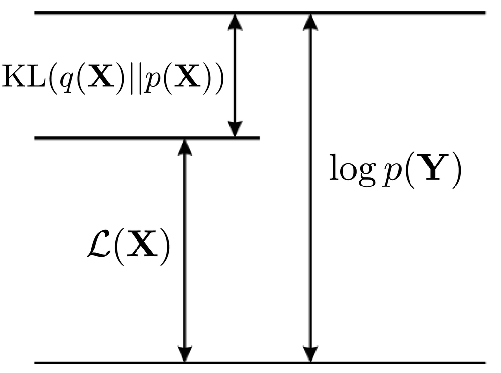